# UFRGS - Especialização em Ciência de Dados SERPRO - INF/UFRGS (2022-2023)

##### **2. Vamos considerar uma nova variável: a diferença entre o peso desejado (wtdesire) e o peso atual (weight). Crie esta nova variável subtraindo as duas colunas na base de dados e atribuindo-as a um novo objeto chamado wdiff.**

- Criando a covariável wdiff e convertendo-a de libras para quilogramas

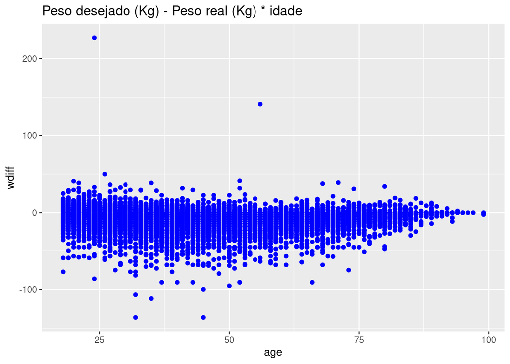

```r
cdc$wdiff = (cdc$wtdesire - cdc$weight) *  0.453592
ggplot(cdc) + geom_point(mapping = aes(x = age, y = wdiff) , color="blue") + ggtitle("Peso desejado (Kg) - Peso real (Kg) * idade")
```

##### **3. Que tipo de dado está contido na variável wdiff? Se uma observação de wdiff é 0, o que isso implica com relação ao peso atual e desejado de uma pessoas? E se o valor de wdiff for positivo ou negativo?**

- Visualização dos 5 primeiros valores ca covariável wdiif

```r
head(cdc$wdiff, 5)
```

```
## [1]  0.000000 -4.535920  0.000000 -3.628736 -9.071840
```

- Tipo da covariável wdiff

```r
typeof(cdc$wdiff)
```

```
## [1] "double"
```

- Covariável wdiff - Descrição*
  - Se wdiff = 0 então a meta de peso ideal estipulada foi alcançada - peso ideal melhor caso
  - Se wdiff < 0 então, tende a sobrepeso
  - Se wdiff > 0 então, tende a subpeso

##### **4. Descreva a distribuição de wdiff em termos de seu centro, forma e variação, incluindo qualquer gráfico que você usar. O que isso nos diz sobre como as pessoas se sentem a respeito do seu peso atual?**

- Curiosamente, conforme gráfico a seguir, a distribuição se concentra em indivíduos que estão satisfeitos com seu atual peso, tendendo a valores de pesos com menores graus desobrepeso.*

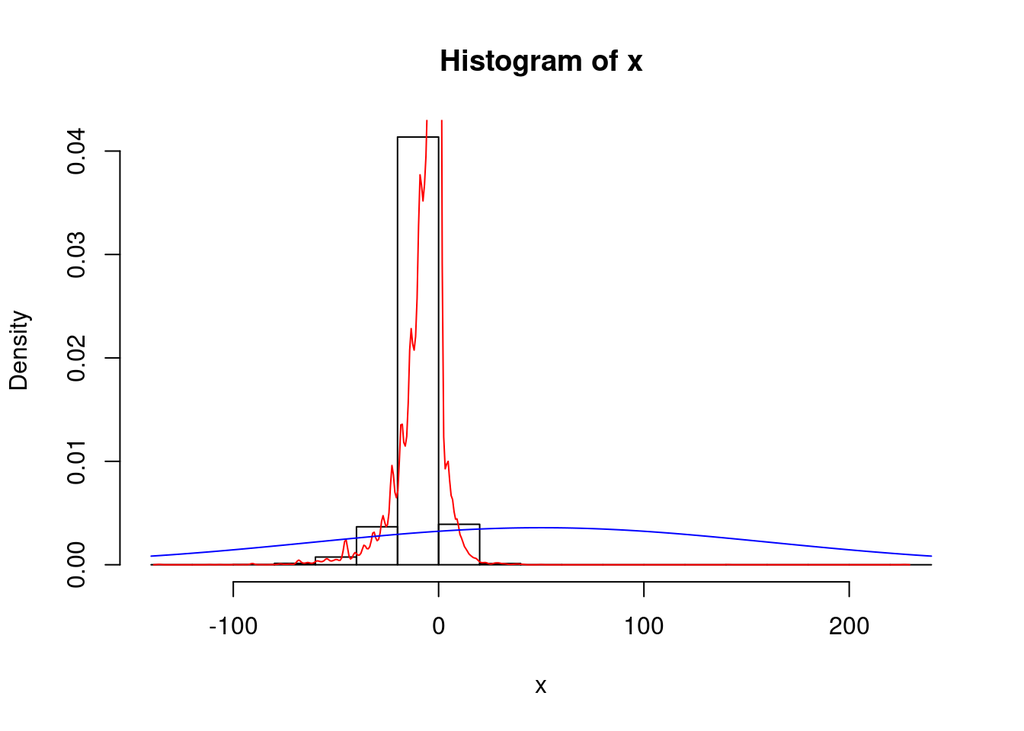

```r
w_wdiff = histogram(cdc$wdiff)
```

##### **5. Utilizando sumários numéricos e um gráfico de caixas lado-a-lado, determine se homens tendem a ver seu peso diferentemente das mulheres.**

- Como observado nos gráficos box plots a seguir, observa-se, no gráfico das mulheres (F), a mediana e o primeiro quartil mais afastados de Zero, se comparado aos homens, ou seja, indicando maior sobrepeso. Já no gráfico dos homens (M), contraditoriamente, a mediana se aproxima mais do zero. Entretanto, se observam mais outlier para valores acima de zero, o que pode ser um indício de indicativo de que homens se imaginam com mais sobrepeso do que, de fato, estão.

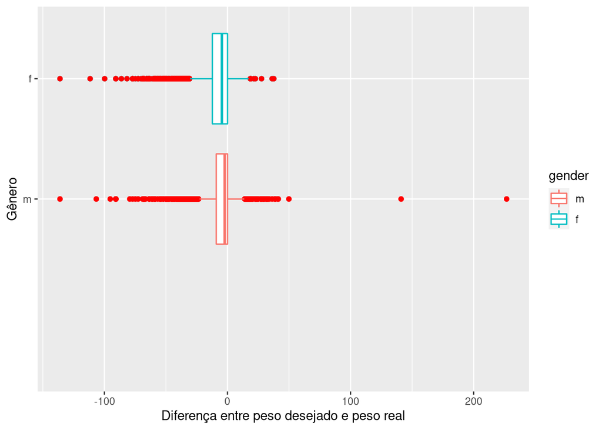

```r
ggplot(cdc, mapping=aes(x=gender, y=wdiff, color=gender))+geom_boxplot()+geom_boxplot(outlier.color = "red")+ xlab("Gênero") +
  ylab("Diferença entre peso desejado e peso real")+coord_flip(xlim=c(0, 2))
```

- Média do peso (em Kg)

```r
mean(cdc$weight) *  0.453592
```

```
## [1] 76.96683
```

- Desvio Padrão

```r
sd(cdc$weight)
```

```
## [1] 40.08097
```

- Análise da normalidade dos pesos no dataset

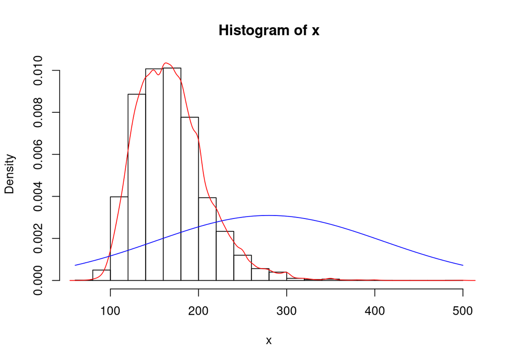

```r
w = histogram(cdc$weight)
```